# Disturbance–response analysis I — central tendency, variance & peak synchrony

Simplest-possible pass: per-series moments + peak-derived synchrony, pre vs post

nic (nic@cascadeclimate.org)

2026-07-18

First, deliberately minimal, pass over the three synthetic series (`synthetic_{shift,desync, return}.csv`; design in `CLAUDE.md`). `response` is a lagged log-linear transform of climate, so every response statistic is taken on **`log(response)`**: there the signal is a clean lagged sinusoid with additive noise, whereas raw `response` is multiplicative / right-skewed and its moments conflate amplitude with skew. Two moves: **(1)** quantify each channel (`climate`, `log(response)`) with central-tendency and variance within the settled `pre`/`post` regimes; **(2)** turn those — plus peak spacings — into a description of **synchrony** (same rate? same strength? what delay?) across the disturbance. Moments (incl. covariance) and peak spacings only — no correlation coefficient, spectra, or wavelets.

Per-*series* moments are blind to co-movement, so we add one **joint** moment — `cov(climate, log(response))` per regime — plus three peak-derived synchrony quantities:

- **period** — mean spacing between successive peaks (per channel);
- **amplitude ratio** — `sd(log(response))/sd(climate) ≈ β` (in log space the signal is a clean sinusoid, so `sd = A/√2` holds; on raw `response` it does not);
- **phase lag** — mean offset of each `log(response)` peak behind the preceding climate peak.

*Error-bar caveat: each settled window spans ~4 cycles (3–5 peaks), so the peak-metric SEs rest on few samples — read them as relative, not exact.*

## Helpers

```r
# centered moving average (window w); NA at the ±(w-1)/2 ends — used for peak-finding only.
smooth_ma <- function(x, w = 51) as.numeric(stats::filter(x, rep(1 / w, w)))

# local maxima of a smoothed copy, thinned greedily by height to a minimum separation `gap`.
# Two noise defences: keep only candidates above the window mean (an oscillation peak sits above
# its central tendency ⇒ drops trough-region ripples), then greedy gap≈0.6P ⇒ ≤1 peak/period.
find_peaks <- function(x, w = 51, gap = 300) {
  s <- smooth_ma(x, w); n <- length(s)
  interior <- s[2:(n - 1)] > s[1:(n - 2)] & s[2:(n - 1)] >= s[3:n]
  cand <- which(c(FALSE, interior, FALSE))            # NA comparisons drop out of which()
  cand <- cand[s[cand] > mean(s, na.rm = TRUE)]       # peaks lie above central tendency
  cand <- cand[order(s[cand], decreasing = TRUE)]     # tallest first
  keep <- integer(0)
  for (i in cand) if (all(abs(i - keep) >= gap)) keep <- c(keep, i)
  sort(keep)
}

# per-channel moments: central tendency (mean, median) + spread (sd, var, IQR, range).
series_stats <- function(x)
  tibble(mean = mean(x), median = median(x), sd = sd(x),
         var = var(x), IQR = IQR(x), range = diff(range(x)))

# per-response-peak offset behind the preceding climate peak, wrapped into [0,P). Empty if either
# channel has no peak. phase_lag = its mean; the vector also feeds the metric's standard error.
peak_offsets <- function(pc, pr) {
  if (!length(pc) || !length(pr)) return(numeric(0))
  vapply(pr, function(tr) {
    prior <- pc[pc <= tr]
    d <- if (length(prior)) tr - max(prior) else tr - min(pc)
    ((d %% P) + P) %% P
  }, numeric(1))
}
se_mean  <- function(x) if (length(x) > 1) sd(x) / sqrt(length(x)) else NA_real_  # SE of a sample mean

# covariance SE from per-cycle estimates: cut the window into P-long blocks, cov within each,
# SE = sd(block covs)/√n_blocks. Valid under autocorrelation — an iid cov SE would be far too
# narrow (effective n is the ~4 cycles, not the ~2000 points). Mirrors the peak-metric SEs.
cov_se <- function(x, y) {
  blk <- (seq_along(x) - 1) %/% P
  cv  <- tapply(seq_along(x), blk, function(i) if (length(i) > 2) cov(x[i], y[i]) else NA_real_)
  se_mean(cv[is.finite(cv)])
}

# synchrony summary for one settled window (climate/response columns). Peaks are found ONCE here
# and every derived quantity — including the mean-type standard errors (period_response_se,
# phase_lag_se) — reuses them, so callers never re-run find_peaks.
# period_resp_sd = spacing irregularity: small ⇒ clean oscillation, large ⇒ decoupled/noise.
sync_one <- function(sub) {
  pc <- find_peaks(sub$climate); pr <- find_peaks(sub$log_response)   # response peaks in log space
  dpr <- diff(pr); off <- peak_offsets(pc, pr)      # spacings / offsets feed both value and SE
  ac <- sd(sub$climate); ar <- sd(sub$log_response) # amp_response = sd(log R) ≈ β; sd computed once
  tibble(n = nrow(sub),
         period_climate     = mean(diff(pc)),
         period_response    = mean(dpr),
         period_response_se = se_mean(dpr),          # SE of the mean inter-peak interval
         period_resp_sd     = sd(dpr),
         amp_climate        = ac,
         amp_response       = ar,
         amp_ratio          = ar / ac,
         phase_lag          = if (length(off)) mean(off) else NA_real_,
         phase_lag_se       = se_mean(off))          # SE of the mean per-peak offset
}

# tables + figure for one dataset, over the settled pre/post regimes (transition excluded).
stats_by_period <- function(df)
  df %>% filter(phase %in% c("pre", "post")) %>%
    pivot_longer(c(climate, log_response), names_to = "series") %>%
    group_by(phase, series) %>% group_modify(~ series_stats(.x$value)) %>% ungroup() %>%
    mutate(phase = factor(phase, c("pre", "post"))) %>% arrange(phase, series)

sync_by_period <- function(df)
  bind_rows(pre  = sync_one(filter(df, phase == "pre")),
            post = sync_one(filter(df, phase == "post")), .id = "phase") %>%
    mutate(phase = factor(phase, c("pre", "post")))

# contiguous phase spans → shaded background bands (disturbance is a single step, drawn as a line).
phase_fill <- c(pre = "#9ecae1", disturbance = "grey45", transition = "#fcbba1", post = "#fdae6b")
plot_series <- function(df, title) {
  bands <- df %>% filter(phase != "disturbance") %>% group_by(phase) %>%
    summarise(xmin = min(time), xmax = max(time), .groups = "drop")
  td <- df$time[df$phase == "disturbance"]
  ggplot() +
    geom_rect(data = bands, aes(xmin = xmin, xmax = xmax, ymin = -Inf, ymax = Inf, fill = phase),
              alpha = 0.35, inherit.aes = FALSE) +
    geom_vline(xintercept = td, linetype = 2, colour = "grey80") +
    geom_line(data = pivot_longer(df, c(climate, log_response), names_to = "var") %>%
                mutate(var = recode(var, log_response = "log(response)")),
              aes(time, value, colour = var), linewidth = 0.3) +
    scale_fill_manual(values = phase_fill, guide = "none") +
    scale_colour_manual(values = c(climate = "grey15", `log(response)` = "#6a51a3")) +
    labs(title = title, x = "time", y = "value", colour = NULL)
}

# bar companions to the two tables; pre/post reuse the phase-band fills. free_y scales
# because metrics live on different units (amp ~1, period ~500, lag ~10s).
bar_fill <- c(pre = "#9ecae1", post = "#fdae6b")
# errbar=TRUE overlays ±1 SE (sd/√n) on the mean facet only. NB with autocorrelated series
# the iid SE is optimistic (too narrow); here it still dwarfs the ~0 means → not distinguishable.
# takes the precomputed stats tibble (stats_by_period) so the moments grid isn't recomputed;
# cov/n are still derived from df (not duplicated elsewhere).
plot_moments <- function(stats_x, df, title, errbar = FALSE) {   # central tendency + spread, per channel
  st <- stats_x %>% select(phase, series, mean, median, sd)
  nn <- df %>% filter(phase %in% c("pre", "post")) %>% count(phase, name = "n")   # rows per window
  # se lives on the wide table (sd/√n), tagged onto the mean rows after the pivot — no self-join.
  long <- st %>% left_join(nn, by = "phase") %>%
    mutate(se_mean = sd / sqrt(n)) %>%
    pivot_longer(c(mean, median, sd), names_to = "measure") %>%
    mutate(se = ifelse(measure == "mean", se_mean, NA_real_)) %>%
    select(phase, series, measure, value, se)
  # joint moment: one cov(climate, log_response) per regime → own facet (single x category).
  # per-cycle SE (see cov_se) — block SE, matching the other metrics.
  cov <- df %>% filter(phase %in% c("pre", "post")) %>% group_by(phase) %>%
    summarise(value = cov(climate, log_response), se = cov_se(climate, log_response), .groups = "drop") %>%
    mutate(phase = factor(phase, c("pre", "post")), series = "clim×log(resp)", measure = "cov")
  long <- bind_rows(long, cov) %>%
    mutate(measure = factor(measure, c("mean", "median", "sd", "cov")))
  ggplot(long, aes(series, value, fill = phase)) +
    geom_col(position = position_dodge(0.8), width = 0.7) +
    { if (errbar) geom_errorbar(aes(ymin = value - se, ymax = value + se),
        position = position_dodge(0.8), width = 0.25, colour = "black", na.rm = TRUE) } +
    facet_wrap(~ measure, scales = "free") +   # free x too: cov facet has its own single category
    scale_fill_manual(values = bar_fill) +
    labs(title = title, x = NULL, y = NULL, fill = NULL)
}

# takes the precomputed sync tibble (sync_by_period), which already carries the mean-type SEs
# (period_response_se, phase_lag_se) — so peaks are never re-found for the error bars.
plot_sync <- function(sync_x, title) {                  # peak-derived synchrony discriminators
  se_long <- sync_x %>%                                 # SE only for the mean-type metrics
    transmute(phase, period_response = period_response_se, phase_lag = phase_lag_se) %>%
    pivot_longer(-phase, names_to = "metric", values_to = "se")
  dat <- sync_x %>% select(phase, period_response, amp_ratio, phase_lag, period_resp_sd) %>%
    pivot_longer(-phase, names_to = "metric") %>%
    left_join(se_long, by = c("phase", "metric")) %>%   # amp_ratio & period_resp_sd → NA (no SE)
    mutate(metric = factor(metric, c("period_response", "amp_ratio", "phase_lag", "period_resp_sd")))
  ggplot(dat, aes(phase, value, fill = phase)) +
    geom_col(width = 0.7) +
    geom_errorbar(aes(ymin = value - se, ymax = value + se), width = 0.25, colour = "black", na.rm = TRUE) +
    facet_wrap(~ metric, scales = "free_y", nrow = 1) +
    scale_fill_manual(values = bar_fill, guide = "none") +
    labs(title = title, x = NULL, y = NULL)
}
```

```r
# response is analyzed in log space (log-linear generator) → add log_response once at load.
d_shift  <- read_csv("synthetic_shift.csv",  show_col_types = FALSE) %>% mutate(log_response = log(response))
d_desync <- read_csv("synthetic_desync.csv", show_col_types = FALSE) %>% mutate(log_response = log(response))
d_return <- read_csv("synthetic_return.csv", show_col_types = FALSE) %>% mutate(log_response = log(response))
```

```r
# Each dataset's moment / synchrony summaries are computed ONCE here (find_peaks runs a single
# time per window) and reused by every table, figure, and the cross-dataset summary below.
stats_shift  <- stats_by_period(d_shift);  sync_shift  <- sync_by_period(d_shift)
stats_desync <- stats_by_period(d_desync); sync_desync <- sync_by_period(d_desync)
stats_return <- stats_by_period(d_return); sync_return <- sync_by_period(d_return)
```

# Shift

Expectation: still synchronous either side of the disturbance, but a **new regime** — response log-amplitude halves (`sd(log R)` ratio `1.0→0.5`, = β) and lag shortens (`50→10`); period unchanged (~P).

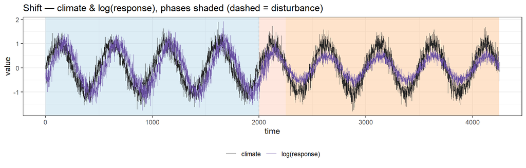

Figure 1. Shift — climate & log(response) over time, phases shaded (dashed = disturbance).

```r
plot_series(d_shift, "Shift — climate & log(response), phases shaded (dashed = disturbance)")
```

```r
cat(kable(stats_shift, digits = 3,
          caption = "Shift — per-channel moments, settled regimes"), sep = "\n")
```

Shift — per-channel moments, settled regimes

| phase | series | mean | median | sd | var | IQR | range |
| --- | --- | --- | --- | --- | --- | --- | --- |
| pre | climate | -0.004 | 0.013 | 0.751 | 0.564 | 1.334 | 3.604 |
| pre | log_response | -0.003 | 0.020 | 0.751 | 0.564 | 1.337 | 3.676 |
| post | climate | -0.009 | -0.016 | 0.753 | 0.567 | 1.352 | 3.480 |
| post | log_response | -0.004 | -0.016 | 0.381 | 0.145 | 0.665 | 1.765 |

```r
cat("\n\n")
```

```r
cat(kable(sync_shift %>% select(-ends_with("_se")), digits = 2,   # SEs shown as error bars, not in table
          caption = "Shift — peak-derived synchrony, pre vs post"), sep = "\n")
```

Shift — peak-derived synchrony, pre vs post

| phase | n | period_climate | period_response | period_resp_sd | amp_climate | amp_response | amp_ratio | phase_lag |
| --- | --- | --- | --- | --- | --- | --- | --- | --- |
| pre | 1999 | 501.33 | 501.33 | 20.98 | 0.75 | 0.75 | 1.00 | 46 |
| post | 2000 | 499.67 | 498.33 | 20.03 | 0.75 | 0.38 | 0.51 | 9 |

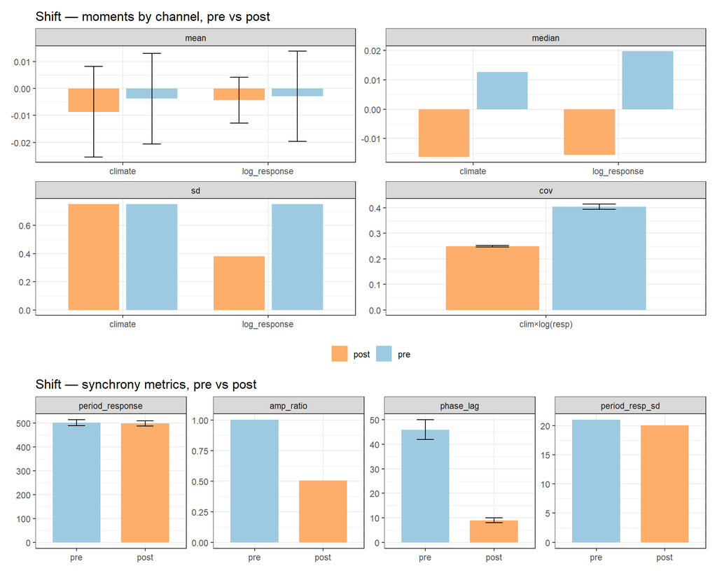

Figure 2. Shift — per-channel moments + joint covariance (top) and peak-derived synchrony metrics (bottom), pre vs post. Error bars = ±1 SE: channel mean and peak metrics (period, phase lag) from their sample spread, covariance from per-cycle estimates; sd / median / amp ratio / period-sd have none.

```r
(plot_moments(stats_shift, d_shift, "Shift — moments by channel, pre vs post", errbar = TRUE) /
 plot_sync(sync_shift, "Shift — synchrony metrics, pre vs post")) +
  plot_layout(heights = c(2, 1))   # 2×2 moments gets twice the height of the 1-row sync strip
```

Read-off: log-amplitude ratio drops toward ~0.5 (= β) and phase lag from ~50 to ~10 while both periods stay ~P — a coherent **regime shift**, not a loss of coupling.

# Desync

Expectation: `pre` synchronous; `post` `log(response)` is stationary Gaussian noise matched to regime-n log-variance — so `amp_response` (= sd(log R)) ≈ preserved, but peak spacing becomes **irregular** (`period_resp_sd` blows up) and phase lag is meaningless. Climate keeps its clean period.

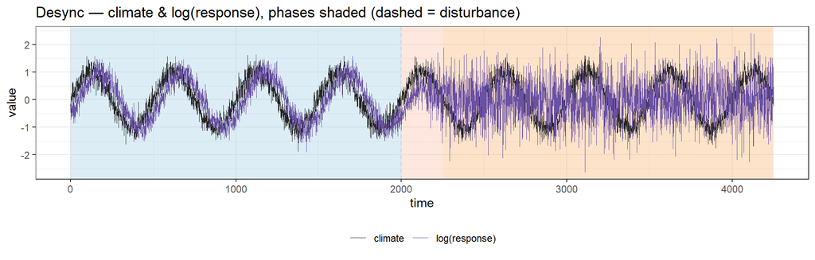

Figure 3. Desync — climate & log(response) over time, phases shaded (dashed = disturbance).

```r
plot_series(d_desync, "Desync — climate & log(response), phases shaded (dashed = disturbance)")
```

```r
cat(kable(stats_desync, digits = 3,
          caption = "Desync — per-channel moments, settled regimes"), sep = "\n")
```

Desync — per-channel moments, settled regimes

| phase | series | mean | median | sd | var | IQR | range |
| --- | --- | --- | --- | --- | --- | --- | --- |
| pre | climate | -0.006 | 0.001 | 0.751 | 0.564 | 1.333 | 3.476 |
| pre | log_response | -0.006 | -0.010 | 0.752 | 0.565 | 1.319 | 3.520 |
| post | climate | -0.001 | 0.004 | 0.760 | 0.577 | 1.356 | 3.473 |
| post | log_response | -0.004 | 0.003 | 0.752 | 0.566 | 1.008 | 5.041 |

```r
cat("\n\n")
```

```r
cat(kable(sync_desync %>% select(-ends_with("_se")), digits = 2,
          caption = "Desync — peak-derived synchrony, pre vs post"), sep = "\n")
```

Desync — peak-derived synchrony, pre vs post

| phase | n | period_climate | period_response | period_resp_sd | amp_climate | amp_response | amp_ratio | phase_lag |
| --- | --- | --- | --- | --- | --- | --- | --- | --- |
| pre | 1999 | 505.00 | 505.00 | 14.42 | 0.75 | 0.75 | 1.00 | 48.25 |
| post | 2000 | 503.33 | 413.25 | 109.39 | 0.76 | 0.75 | 0.99 | 238.40 |

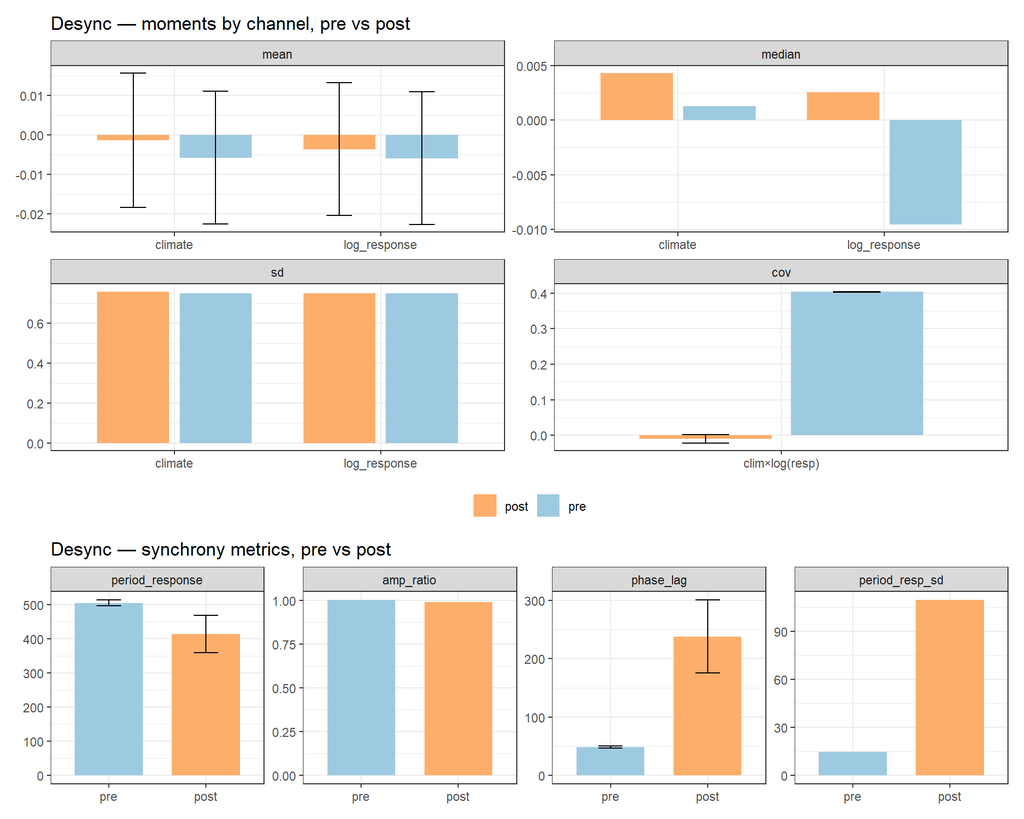

Figure 4. Desync — per-channel moments + joint covariance (top) and peak-derived synchrony metrics (bottom), pre vs post. Error bars = ±1 SE: channel mean and peak metrics (period, phase lag) from their sample spread, covariance from per-cycle estimates; sd / median / amp ratio / period-sd have none.

```r
(plot_moments(stats_desync, d_desync, "Desync — moments by channel, pre vs post", errbar = TRUE) /
 plot_sync(sync_desync, "Desync — synchrony metrics, pre vs post")) +
  plot_layout(heights = c(2, 1))
```

# Return

Expectation: `pre` and `post` are the **same regime n** (the response decouples into noise then recovers), so every moment and synchrony metric should match end-to-end.

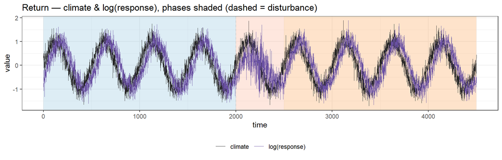

Figure 5. Return — climate & log(response) over time, phases shaded (dashed = disturbance).

```r
plot_series(d_return, "Return — climate & log(response), phases shaded (dashed = disturbance)")
```

```r
cat(kable(stats_return, digits = 3,
          caption = "Return — per-channel moments, settled regimes"), sep = "\n")
```

Return — per-channel moments, settled regimes

| phase | series | mean | median | sd | var | IQR | range |
| --- | --- | --- | --- | --- | --- | --- | --- |
| pre | climate | 0.004 | -0.016 | 0.742 | 0.550 | 1.317 | 3.394 |
| pre | log_response | 0.006 | -0.011 | 0.744 | 0.553 | 1.291 | 3.335 |
| post | climate | 0.010 | 0.031 | 0.754 | 0.569 | 1.336 | 3.598 |
| post | log_response | 0.009 | 0.020 | 0.755 | 0.570 | 1.339 | 3.545 |

```r
cat("\n\n")
```

```r
cat(kable(sync_return %>% select(-ends_with("_se")), digits = 2,
          caption = "Return — peak-derived synchrony, pre vs post"), sep = "\n")
```

Return — peak-derived synchrony, pre vs post

| phase | n | period_climate | period_response | period_resp_sd | amp_climate | amp_response | amp_ratio | phase_lag |
| --- | --- | --- | --- | --- | --- | --- | --- | --- |
| pre | 1999 | 506 | 501.67 | 19.04 | 0.74 | 0.74 | 1 | 53.5 |
| post | 2000 | 491 | 491.00 | 14.18 | 0.75 | 0.75 | 1 | 50.0 |

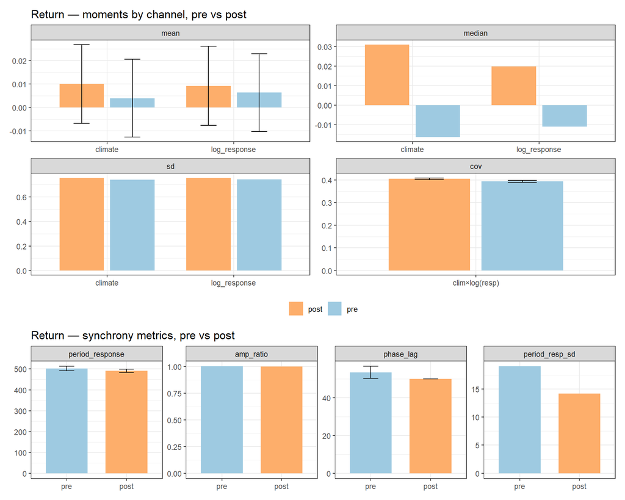

Figure 6. Return — per-channel moments + joint covariance (top) and peak-derived synchrony metrics (bottom), pre vs post. Error bars = ±1 SE: channel mean and peak metrics (period, phase lag) from their sample spread, covariance from per-cycle estimates; sd / median / amp ratio / period-sd have none.

```r
(plot_moments(stats_return, d_return, "Return — moments by channel, pre vs post", errbar = TRUE) /
 plot_sync(sync_return, "Return — synchrony metrics, pre vs post")) +
  plot_layout(heights = c(2, 1))
```

Read-off: pre ≈ post on every measure — the disturbance leaves **no lasting signature** in these statistics.

# Cross-dataset summary

Post-minus-pre change in the two synchrony discriminators. Shift moves amplitude ratio and lag together; Desync spikes response-period irregularity; Return sits at the origin.

```r
sync_all <- bind_rows(Shift = sync_shift, Desync = sync_desync,   # reuse the summaries from `derive`
                      Return = sync_return, .id = "dataset")

# pre→post deltas of the discriminating metrics
delta <- sync_all %>%
  select(dataset, phase, amp_ratio, phase_lag, period_resp_sd) %>%
  pivot_longer(c(amp_ratio, phase_lag, period_resp_sd), names_to = "metric") %>%
  pivot_wider(names_from = phase, values_from = value) %>%
  mutate(delta = post - pre,
         dataset = factor(dataset, c("Shift", "Desync", "Return")))
```

```r
cat(kable(delta %>% select(dataset, metric, pre, post, delta), digits = 2,
          caption = "pre → post change in synchrony discriminators, all datasets"), sep = "\n")
```

pre → post change in synchrony discriminators, all datasets

| dataset | metric | pre | post | delta |
| --- | --- | --- | --- | --- |
| Shift | amp_ratio | 1.00 | 0.51 | -0.49 |
| Shift | phase_lag | 46.00 | 9.00 | -37.00 |
| Shift | period_resp_sd | 20.98 | 20.03 | -0.95 |
| Desync | amp_ratio | 1.00 | 0.99 | -0.01 |
| Desync | phase_lag | 48.25 | 238.40 | 190.15 |
| Desync | period_resp_sd | 14.42 | 109.39 | 94.97 |
| Return | amp_ratio | 1.00 | 1.00 | 0.00 |
| Return | phase_lag | 53.50 | 50.00 | -3.50 |
| Return | period_resp_sd | 19.04 | 14.18 | -4.86 |

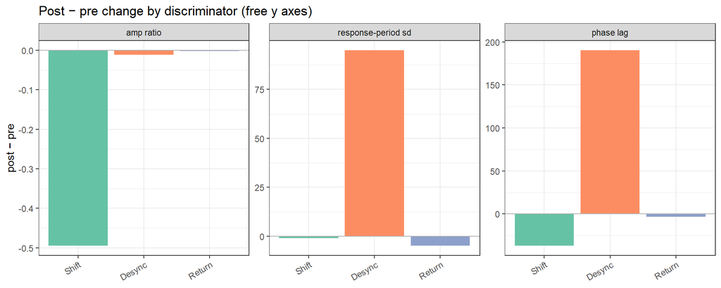

Figure 7. Post − pre change per scenario, faceted by discriminator with free y axes (so scenarios compare within each metric — the three live on very different scales). Shift moves amp-ratio & lag; Desync spikes response-period sd; Return ≈ 0 everywhere.

```r
ggplot(delta, aes(dataset, delta, fill = dataset)) +
  geom_col() +
  geom_hline(yintercept = 0, colour = "grey70") +
  facet_wrap(~ metric, scales = "free_y",       # free_y: these discriminators live on different scales
             labeller = as_labeller(c(amp_ratio = "amp ratio", phase_lag = "phase lag",
                                      period_resp_sd = "response-period sd"))) +
  scale_fill_brewer(palette = "Set2", guide = "none") +
  labs(title = "Post − pre change by discriminator (free y axes)", x = NULL, y = "post − pre") +
  theme(axis.text.x = element_text(angle = 30, hjust = 1))
```